# Cocktail/premix stability assesment

Aguirre

2024-04-07

## # Marker studied: CD5_mfi

```r
knitr::opts_chunk$set(echo = TRUE)
```

## Supporting functions

The following functions are designed to transform and visualize the data: * `df_format()` reshapes the dataframe for analysis * `markers_violin()` creates violin plots to visualize the distribution of marker values across different days.

## ploting values of CD5 through time

The violin plot visualizes the distribution of marker values over time, offering an initial visual assessment of the stability of the antibody cocktail/premix.

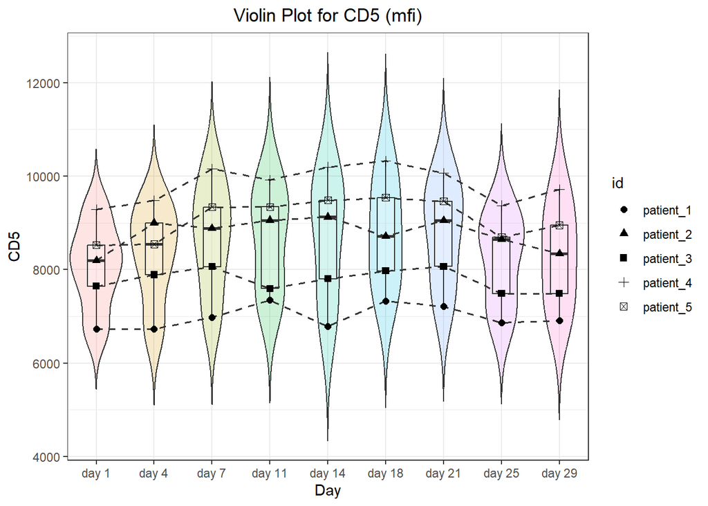

Interpretation: The violin plot provides a visual assessment of the data’s distribution across different days. Consistency in the shape of the distributions across days suggests stability in the reagent’s performance over time. Significant variation could indicate instability or a change in reagent performance.

## ANOVA to test if the mean of the measures for CD5 are different between each day

ANOVA is performed to test if there are statistically significant differences in the mean values of the measures across different days. It helps in understanding if the stability of the antibody cocktail changes over time.

```r
print(head(df_melt))
```

```
##          id marker   day    value
## 1 patient_1    CD5 day 1 6729.310
## 2 patient_2    CD5 day 1 8197.600
## 3 patient_3    CD5 day 1 7644.774
## 4 patient_4    CD5 day 1 9287.812
## 5 patient_5    CD5 day 1 8526.617
## 6 patient_1    CD5 day 4 6728.820
```

```r
aov_out = aov(value~day, data = df_melt)
print(summary(aov_out))
```

```
##             Df   Sum Sq Mean Sq F value Pr(>F)
## day          8  2893401  361675   0.279  0.969
## Residuals   36 46732118 1298114
```

Interpretation: A p-value less than 0.05 from the ANOVA test suggests that there are significant differences in the mean values across days, indicating potential instability in the reagent over time. A p-value greater than 0.05 suggests that the means are not significantly different, indicating stability.

## TUKEY test

Following ANOVA, the Tukey post hoc test is conducted to identify specifically between which days the differences occur. This test is crucial for pinpointing the days that contribute to the overall difference detected by ANOVA.

```r
tukey_out = TukeyHSD(aov_out)
print(tukey_out)
```

```
##   Tukey multiple comparisons of means
##     95% family-wise confidence level
##
## Fit: aov(formula = value ~ day, data = df_melt)
##
## $day
##                    diff       lwr      upr     p adj
## day 4-day 1    251.4784 -2124.362 2627.319 0.9999918
## day 7-day 1    606.4814 -1769.359 2982.322 0.9945973
## day 11-day 1   574.7286 -1801.112 2950.569 0.9962459
## day 14-day 1   603.7992 -1772.041 2979.640 0.9947557
## day 18-day 1   699.6726 -1676.168 3075.513 0.9862698
## day 21-day 1   694.7026 -1681.138 3070.543 0.9868764
## day 25-day 1   136.0856 -2239.755 2511.926 0.9999999
## day 29-day 1   202.9566 -2172.884 2578.797 0.9999985
## day 7-day 4    355.0030 -2020.837 2730.843 0.9998847
## day 11-day 4   323.2502 -2052.590 2699.091 0.9999433
## day 14-day 4   352.3208 -2023.520 2728.161 0.9998911
## day 18-day 4   448.1942 -1927.646 2824.035 0.9993519
## day 21-day 4   443.2242 -1932.616 2819.065 0.9994024
## day 25-day 4  -115.3928 -2491.233 2260.448 1.0000000
## day 29-day 4   -48.5218 -2424.362 2327.319 1.0000000
## day 11-day 7   -31.7528 -2407.593 2344.088 1.0000000
## day 14-day 7    -2.6822 -2378.523 2373.158 1.0000000
## day 18-day 7    93.1912 -2282.649 2469.032 1.0000000
## day 21-day 7    88.2212 -2287.619 2464.062 1.0000000
## day 25-day 7  -470.3958 -2846.236 1905.445 0.9990806
## day 29-day 7  -403.5248 -2779.365 1972.316 0.9996999
## day 14-day 11   29.0706 -2346.770 2404.911 1.0000000
## day 18-day 11  124.9440 -2250.896 2500.784 1.0000000
## day 21-day 11  119.9740 -2255.866 2495.814 1.0000000
## day 25-day 11 -438.6430 -2814.483 1937.197 0.9994460
## day 29-day 11 -371.7720 -2747.612 2004.068 0.9998370
## day 18-day 14   95.8734 -2279.967 2471.714 1.0000000
## day 21-day 14   90.9034 -2284.937 2466.744 1.0000000
## day 25-day 14 -467.7136 -2843.554 1908.127 0.9991177
## day 29-day 14 -400.8426 -2776.683 1974.998 0.9997144
## day 21-day 18   -4.9700 -2380.810 2370.870 1.0000000
## day 25-day 18 -563.5870 -2939.427 1812.253 0.9967170
## day 29-day 18 -496.7160 -2872.556 1879.124 0.9986429
## day 25-day 21 -558.6170 -2934.457 1817.223 0.9969111
## day 29-day 21 -491.7460 -2867.586 1884.094 0.9987366
## day 29-day 25   66.8710 -2308.969 2442.711 1.0000000
```

Interpretation: The Tukey post hoc test helps identify specific pairs of days between which significant differences exist. If certain days are identified as significantly different, this could pinpoint when changes in the reagent’s stability occur. No significant pairwise differences would support the reagent’s stability across the evaluated period.

## Repeated Measures ANOVA

This section involves a repeated measures ANOVA, which accounts for the same reagent being measured across different days. It provides a more precise analysis of the data considering the repeated measures aspect.

```r
aov_out_repeated = aov(value~day + Error(id), data = df_melt)
print(summary(aov_out_repeated))
```

```
##
## Error: id
##           Df   Sum Sq  Mean Sq F value Pr(>F)
## Residuals  4 45206157 11301539
##
## Error: Within
##           Df  Sum Sq Mean Sq F value   Pr(>F)
## day        8 2893401  361675   7.584 1.22e-05 ***
## Residuals 32 1525961   47686
## ---
## Signif. codes:  0 '***' 0.001 '**' 0.01 '*' 0.05 '.' 0.1 ' ' 1
```

Interpretation: Significant results (p < 0.05) indicate that there is a change in reagent performance over time when accounting for repeated measurements. This suggests instability in the reagent’s effectiveness across the days tested.

## Pairwise t-test with Bonferroni adjustment

The pairwise t-test compares the means between each pair of days, adjusting for multiple comparisons using the Bonferroni method. It further explores the specific days between which significant differences exist.

```r
pwc <- df_melt %>%
    pairwise_t_test(
      value ~ day, paired = TRUE,
      p.adjust.method = "bonferroni"
    )
print(kable(as.data.frame(pwc)))
```

```
##
##
## |.y.   |group1 |group2 | n1| n2|  statistic| df|        p| p.adj|p.adj.signif |
## |:-----|:------|:------|--:|--:|----------:|--:|--------:|-----:|:------------|
## |value |day 1  |day 4  |  5|  5| -1.7234960|  4| 0.160000| 1.000|ns           |
## |value |day 1  |day 7  |  5|  5| -5.1287596|  4| 0.007000| 0.246|ns           |
## |value |day 1  |day 11 |  5|  5| -3.5137854|  4| 0.025000| 0.886|ns           |
## |value |day 1  |day 14 |  5|  5| -2.9841034|  4| 0.041000| 1.000|ns           |
## |value |day 1  |day 18 |  5|  5| -4.9875264|  4| 0.008000| 0.272|ns           |
## |value |day 1  |day 21 |  5|  5| -6.7940916|  4| 0.002000| 0.088|ns           |
## |value |day 1  |day 25 |  5|  5| -1.4148465|  4| 0.230000| 1.000|ns           |
## |value |day 1  |day 29 |  5|  5| -1.8827341|  4| 0.133000| 1.000|ns           |
## |value |day 4  |day 7  |  5|  5| -2.1175872|  4| 0.102000| 1.000|ns           |
## |value |day 4  |day 11 |  5|  5| -1.6362358|  4| 0.177000| 1.000|ns           |
## |value |day 4  |day 14 |  5|  5| -1.7516291|  4| 0.155000| 1.000|ns           |
## |value |day 4  |day 18 |  5|  5| -1.8626971|  4| 0.136000| 1.000|ns           |
## |value |day 4  |day 21 |  5|  5| -2.8830769|  4| 0.045000| 1.000|ns           |
## |value |day 4  |day 25 |  5|  5|  0.9854562|  4| 0.380000| 1.000|ns           |
## |value |day 4  |day 29 |  5|  5|  0.2368031|  4| 0.824000| 1.000|ns           |
## |value |day 7  |day 11 |  5|  5|  0.2145656|  4| 0.841000| 1.000|ns           |
## |value |day 7  |day 14 |  5|  5|  0.0277468|  4| 0.979000| 1.000|ns           |
## |value |day 7  |day 18 |  5|  5| -0.9566085|  4| 0.393000| 1.000|ns           |
## |value |day 7  |day 21 |  5|  5| -1.5325715|  4| 0.200000| 1.000|ns           |
## |value |day 7  |day 25 |  5|  5|  3.6907508|  4| 0.021000| 0.756|ns           |
## |value |day 7  |day 29 |  5|  5|  4.4603587|  4| 0.011000| 0.403|ns           |
## |value |day 11 |day 14 |  5|  5| -0.1936275|  4| 0.856000| 1.000|ns           |
## |value |day 11 |day 18 |  5|  5| -0.9002294|  4| 0.419000| 1.000|ns           |
## |value |day 11 |day 21 |  5|  5| -1.1731672|  4| 0.306000| 1.000|ns           |
## |value |day 11 |day 25 |  5|  5|  4.7477810|  4| 0.009000| 0.324|ns           |
## |value |day 11 |day 29 |  5|  5|  3.5331271|  4| 0.024000| 0.871|ns           |
## |value |day 14 |day 18 |  5|  5| -0.6275500|  4| 0.564000| 1.000|ns           |
## |value |day 14 |day 21 |  5|  5| -0.8511468|  4| 0.443000| 1.000|ns           |
## |value |day 14 |day 25 |  5|  5|  2.8036620|  4| 0.049000| 1.000|ns           |
## |value |day 14 |day 29 |  5|  5|  2.6667498|  4| 0.056000| 1.000|ns           |
## |value |day 18 |day 21 |  5|  5|  0.0487130|  4| 0.963000| 1.000|ns           |
## |value |day 18 |day 25 |  5|  5|  3.5859331|  4| 0.023000| 0.828|ns           |
## |value |day 18 |day 29 |  5|  5| 10.7927296|  4| 0.000418| 0.015|*            |
## |value |day 21 |day 25 |  5|  5|  6.8019902|  4| 0.002000| 0.088|ns           |
## |value |day 21 |day 29 |  5|  5|  6.5848039|  4| 0.003000| 0.099|ns           |
## |value |day 25 |day 29 |  5|  5| -0.5905261|  4| 0.587000| 1.000|ns           |
```

Interpretation: This analysis provides detailed comparisons between each pair of days. Significant results after Bonferroni adjustment are strong evidence of a difference in means between specific days, further pinpointing periods of instability.

## Friedman test

The Friedman test, a non-parametric alternative to the repeated measures ANOVA, is used to detect differences in the rankings across multiple related groups. It’s particularly useful when the data does not meet the normality assumption.

```r
# make  a matrix suitable for friedman test
df_simple <- df
df_simple$marker <- NULL

# run FRiedman test
friedm <- friedman.test(as.matrix(df_simple))
print(friedm)
```

```
##
##  Friedman rank sum test
##
## data:  as.matrix(df_simple)
## Friedman chi-squared = 45.309, df = 10, p-value =
## 1.913e-06
```

Interpretation: A significant Friedman test result indicates that there are differences in the reagent’s performance across different days, suggesting potential instability in conditions where the assumption of normality is not met.

## Detailed analysis for Friedman test with Wilcoxon test

After identifying overall differences with the Friedman test, a detailed pairwise comparison using the Wilcoxon test is conducted. It examines specific pairs of days for significant differences, adjusted with the Bonferroni method for multiple comparisons.

```r
pwc <- df_melt %>%
  wilcox_test(
    value ~ day, paired = TRUE,
    p.adjust.method = "bonferroni")
print(kable(as.data.frame(pwc)))
```

```
##
##
## |.y.   |group1 |group2 | n1| n2| statistic|     p| p.adj|p.adj.signif |
## |:-----|:------|:------|--:|--:|---------:|-----:|-----:|:------------|
## |value |day 1  |day 4  |  5|  5|         1| 0.125|     1|ns           |
## |value |day 1  |day 7  |  5|  5|         0| 0.062|     1|ns           |
## |value |day 1  |day 11 |  5|  5|         1| 0.125|     1|ns           |
## |value |day 1  |day 14 |  5|  5|         0| 0.062|     1|ns           |
## |value |day 1  |day 18 |  5|  5|         0| 0.062|     1|ns           |
## |value |day 1  |day 21 |  5|  5|         0| 0.062|     1|ns           |
## |value |day 1  |day 25 |  5|  5|         3| 0.312|     1|ns           |
## |value |day 1  |day 29 |  5|  5|         2| 0.188|     1|ns           |
## |value |day 4  |day 7  |  5|  5|         1| 0.125|     1|ns           |
## |value |day 4  |day 11 |  5|  5|         2| 0.188|     1|ns           |
## |value |day 4  |day 14 |  5|  5|         2| 0.188|     1|ns           |
## |value |day 4  |day 18 |  5|  5|         2| 0.188|     1|ns           |
## |value |day 4  |day 21 |  5|  5|         0| 0.062|     1|ns           |
## |value |day 4  |day 25 |  5|  5|        10| 0.625|     1|ns           |
## |value |day 4  |day 29 |  5|  5|         8| 1.000|     1|ns           |
## |value |day 7  |day 11 |  5|  5|         8| 1.000|     1|ns           |
## |value |day 7  |day 14 |  5|  5|         8| 1.000|     1|ns           |
## |value |day 7  |day 18 |  5|  5|         4| 0.438|     1|ns           |
## |value |day 7  |day 21 |  5|  5|         2| 0.188|     1|ns           |
## |value |day 7  |day 25 |  5|  5|        15| 0.062|     1|ns           |
## |value |day 7  |day 29 |  5|  5|        15| 0.062|     1|ns           |
## |value |day 11 |day 14 |  5|  5|         5| 0.625|     1|ns           |
## |value |day 11 |day 18 |  5|  5|         4| 0.438|     1|ns           |
## |value |day 11 |day 21 |  5|  5|         4| 0.438|     1|ns           |
## |value |day 11 |day 25 |  5|  5|        15| 0.062|     1|ns           |
## |value |day 11 |day 29 |  5|  5|        15| 0.062|     1|ns           |
## |value |day 14 |day 18 |  5|  5|         4| 0.438|     1|ns           |
## |value |day 14 |day 21 |  5|  5|         6| 0.812|     1|ns           |
## |value |day 14 |day 25 |  5|  5|        14| 0.125|     1|ns           |
## |value |day 14 |day 29 |  5|  5|        14| 0.125|     1|ns           |
## |value |day 18 |day 21 |  5|  5|         8| 1.000|     1|ns           |
## |value |day 18 |day 25 |  5|  5|        15| 0.062|     1|ns           |
## |value |day 18 |day 29 |  5|  5|        15| 0.062|     1|ns           |
## |value |day 21 |day 25 |  5|  5|        15| 0.062|     1|ns           |
## |value |day 21 |day 29 |  5|  5|        15| 0.062|     1|ns           |
## |value |day 25 |day 29 |  5|  5|         5| 0.625|     1|ns           |
```

Interpretation: Like the pairwise t-test with Bonferroni adjustment, significant results in the Wilcoxon test indicate specific days between which the reagent’s performance varies significantly, useful for identifying non-parametric indications of instability.

## CONCLUSION for CD5

If repeated ANOVA and Wilcoxon test did not reach significancy, the reagent is stable for the duration assessed